# Midterm 2

Jessica Rico

2021-02-23

## Instructions

Answer the following questions and complete the exercises in RMarkdown. Please embed all of your code and push your final work to your repository. Your code should be organized, clean, and run free from errors. Be sure to **add your name** to the author header above. You may use any resources to answer these questions (including each other), but you may not post questions to Open Stacks or external help sites. There are 10 total questions.

Make sure to use the formatting conventions of RMarkdown to make your report neat and clean! Your plots should use consistent aesthetics throughout. Feel free to be creative- there are many possible solutions to these questions!

This exam is due by **12:00p on Tuesday, February 23**.

## Load the libraries

```r
library(tidyverse)
library(janitor)
library(here)
library(RColorBrewer)
library(paletteer)
library(skimr)
library(ggthemes)
library(naniar)
library(ggpubr)
options(scipen=999) #disables scientific notation when printing
```

## Gapminder

For this assignment, we are going to use data from [gapminder](https://www.gapminder.org/). Gapminder includes information about economics, population, social issues, and life expectancy from countries all over the world. We will use three data sets, so please load all three.

One thing to note is that the data include years beyond 2021. These are projections based on modeling done by the gapminder organization. Start by importing the data.

```r
population <- read_csv(here("midterm2", "data", "population_total.csv"))
population
```

```
## # A tibble: 195 x 302
##    country `1800` `1801` `1802` `1803` `1804` `1805` `1806` `1807` `1808` `1809`
##    <chr>    <dbl>  <dbl>  <dbl>  <dbl>  <dbl>  <dbl>  <dbl>  <dbl>  <dbl>  <dbl>
##  1 Afghan~ 3.28e6 3.28e6 3.28e6 3.28e6 3.28e6 3.28e6 3.28e6 3.28e6 3.28e6 3.28e6
##  2 Albania 4.00e5 4.02e5 4.04e5 4.05e5 4.07e5 4.09e5 4.11e5 4.13e5 4.14e5 4.16e5
##  3 Algeria 2.50e6 2.51e6 2.52e6 2.53e6 2.54e6 2.55e6 2.56e6 2.56e6 2.57e6 2.58e6
##  4 Andorra 2.65e3 2.65e3 2.65e3 2.65e3 2.65e3 2.65e3 2.65e3 2.65e3 2.65e3 2.65e3
##  5 Angola  1.57e6 1.57e6 1.57e6 1.57e6 1.57e6 1.57e6 1.57e6 1.57e6 1.57e6 1.57e6
##  6 Antigu~ 3.70e4 3.70e4 3.70e4 3.70e4 3.70e4 3.70e4 3.70e4 3.70e4 3.70e4 3.70e4
##  7 Argent~ 5.34e5 5.20e5 5.06e5 4.92e5 4.79e5 4.66e5 4.53e5 4.41e5 4.29e5 4.17e5
##  8 Armenia 4.13e5 4.13e5 4.13e5 4.13e5 4.13e5 4.13e5 4.13e5 4.13e5 4.13e5 4.13e5
##  9 Austra~ 2.00e5 2.05e5 2.11e5 2.16e5 2.22e5 2.27e5 2.33e5 2.39e5 2.46e5 2.52e5
## 10 Austria 3.00e6 3.02e6 3.04e6 3.05e6 3.07e6 3.09e6 3.11e6 3.12e6 3.14e6 3.16e6
## # ... with 185 more rows, and 291 more variables: `1810` <dbl>, `1811` <dbl>,
## #   `1812` <dbl>, `1813` <dbl>, `1814` <dbl>, `1815` <dbl>, `1816` <dbl>,
## #   `1817` <dbl>, `1818` <dbl>, `1819` <dbl>, `1820` <dbl>, `1821` <dbl>,
## #   `1822` <dbl>, `1823` <dbl>, `1824` <dbl>, `1825` <dbl>, `1826` <dbl>,
## #   `1827` <dbl>, `1828` <dbl>, `1829` <dbl>, `1830` <dbl>, `1831` <dbl>,
## #   `1832` <dbl>, `1833` <dbl>, `1834` <dbl>, `1835` <dbl>, `1836` <dbl>,
## #   `1837` <dbl>, `1838` <dbl>, `1839` <dbl>, `1840` <dbl>, `1841` <dbl>,
## #   `1842` <dbl>, `1843` <dbl>, `1844` <dbl>, `1845` <dbl>, `1846` <dbl>,
## #   `1847` <dbl>, `1848` <dbl>, `1849` <dbl>, `1850` <dbl>, `1851` <dbl>,
## #   `1852` <dbl>, `1853` <dbl>, `1854` <dbl>, `1855` <dbl>, `1856` <dbl>,
## #   `1857` <dbl>, `1858` <dbl>, `1859` <dbl>, `1860` <dbl>, `1861` <dbl>,
## #   `1862` <dbl>, `1863` <dbl>, `1864` <dbl>, `1865` <dbl>, `1866` <dbl>,
## #   `1867` <dbl>, `1868` <dbl>, `1869` <dbl>, `1870` <dbl>, `1871` <dbl>,
## #   `1872` <dbl>, `1873` <dbl>, `1874` <dbl>, `1875` <dbl>, `1876` <dbl>,
## #   `1877` <dbl>, `1878` <dbl>, `1879` <dbl>, `1880` <dbl>, `1881` <dbl>,
## #   `1882` <dbl>, `1883` <dbl>, `1884` <dbl>, `1885` <dbl>, `1886` <dbl>,
## #   `1887` <dbl>, `1888` <dbl>, `1889` <dbl>, `1890` <dbl>, `1891` <dbl>,
## #   `1892` <dbl>, `1893` <dbl>, `1894` <dbl>, `1895` <dbl>, `1896` <dbl>,
## #   `1897` <dbl>, `1898` <dbl>, `1899` <dbl>, `1900` <dbl>, `1901` <dbl>,
## #   `1902` <dbl>, `1903` <dbl>, `1904` <dbl>, `1905` <dbl>, `1906` <dbl>,
## #   `1907` <dbl>, `1908` <dbl>, `1909` <dbl>, ...
```

```r
income <- read_csv(here("midterm2", "data", "income_per_person_gdppercapita_ppp_inflation_adjusted.csv"))
income
```

```
## # A tibble: 193 x 242
##    country `1800` `1801` `1802` `1803` `1804` `1805` `1806` `1807` `1808` `1809`
##    <chr>    <dbl>  <dbl>  <dbl>  <dbl>  <dbl>  <dbl>  <dbl>  <dbl>  <dbl>  <dbl>
##  1 Afghan~    603    603    603    603    603    603    603    603    603    603
##  2 Albania    667    667    667    667    667    668    668    668    668    668
##  3 Algeria    715    716    717    718    719    720    721    722    723    724
##  4 Andorra   1200   1200   1200   1200   1210   1210   1210   1210   1220   1220
##  5 Angola     618    620    623    626    628    631    634    637    640    642
##  6 Antigu~    757    757    757    757    757    757    757    758    758    758
##  7 Argent~   1640   1640   1650   1650   1660   1660   1670   1680   1680   1690
##  8 Armenia    514    514    514    514    514    514    514    514    514    514
##  9 Austra~    817    822    826    831    836    841    845    850    855    860
## 10 Austria   1850   1850   1860   1870   1880   1880   1890   1900   1910   1920
## # ... with 183 more rows, and 231 more variables: `1810` <dbl>, `1811` <dbl>,
## #   `1812` <dbl>, `1813` <dbl>, `1814` <dbl>, `1815` <dbl>, `1816` <dbl>,
## #   `1817` <dbl>, `1818` <dbl>, `1819` <dbl>, `1820` <dbl>, `1821` <dbl>,
## #   `1822` <dbl>, `1823` <dbl>, `1824` <dbl>, `1825` <dbl>, `1826` <dbl>,
## #   `1827` <dbl>, `1828` <dbl>, `1829` <dbl>, `1830` <dbl>, `1831` <dbl>,
## #   `1832` <dbl>, `1833` <dbl>, `1834` <dbl>, `1835` <dbl>, `1836` <dbl>,
## #   `1837` <dbl>, `1838` <dbl>, `1839` <dbl>, `1840` <dbl>, `1841` <dbl>,
## #   `1842` <dbl>, `1843` <dbl>, `1844` <dbl>, `1845` <dbl>, `1846` <dbl>,
## #   `1847` <dbl>, `1848` <dbl>, `1849` <dbl>, `1850` <dbl>, `1851` <dbl>,
## #   `1852` <dbl>, `1853` <dbl>, `1854` <dbl>, `1855` <dbl>, `1856` <dbl>,
## #   `1857` <dbl>, `1858` <dbl>, `1859` <dbl>, `1860` <dbl>, `1861` <dbl>,
## #   `1862` <dbl>, `1863` <dbl>, `1864` <dbl>, `1865` <dbl>, `1866` <dbl>,
## #   `1867` <dbl>, `1868` <dbl>, `1869` <dbl>, `1870` <dbl>, `1871` <dbl>,
## #   `1872` <dbl>, `1873` <dbl>, `1874` <dbl>, `1875` <dbl>, `1876` <dbl>,
## #   `1877` <dbl>, `1878` <dbl>, `1879` <dbl>, `1880` <dbl>, `1881` <dbl>,
## #   `1882` <dbl>, `1883` <dbl>, `1884` <dbl>, `1885` <dbl>, `1886` <dbl>,
## #   `1887` <dbl>, `1888` <dbl>, `1889` <dbl>, `1890` <dbl>, `1891` <dbl>,
## #   `1892` <dbl>, `1893` <dbl>, `1894` <dbl>, `1895` <dbl>, `1896` <dbl>,
## #   `1897` <dbl>, `1898` <dbl>, `1899` <dbl>, `1900` <dbl>, `1901` <dbl>,
## #   `1902` <dbl>, `1903` <dbl>, `1904` <dbl>, `1905` <dbl>, `1906` <dbl>,
## #   `1907` <dbl>, `1908` <dbl>, `1909` <dbl>, ...
```

```r
life_expectancy <- read_csv(here("midterm2", "data", "life_expectancy_years.csv"))
life_expectancy
```

```
## # A tibble: 187 x 302
##    country `1800` `1801` `1802` `1803` `1804` `1805` `1806` `1807` `1808` `1809`
##    <chr>    <dbl>  <dbl>  <dbl>  <dbl>  <dbl>  <dbl>  <dbl>  <dbl>  <dbl>  <dbl>
##  1 Afghan~   28.2   28.2   28.2   28.2   28.2   28.2   28.1   28.1   28.1   28.1
##  2 Albania   35.4   35.4   35.4   35.4   35.4   35.4   35.4   35.4   35.4   35.4
##  3 Algeria   28.8   28.8   28.8   28.8   28.8   28.8   28.8   28.8   28.8   28.8
##  4 Andorra   NA     NA     NA     NA     NA     NA     NA     NA     NA     NA
##  5 Angola    27     27     27     27     27     27     27     27     27     27
##  6 Antigu~   33.5   33.5   33.5   33.5   33.5   33.5   33.5   33.5   33.5   33.5
##  7 Argent~   33.2   33.2   33.2   33.2   33.2   33.2   33.2   33.2   33.2   33.2
##  8 Armenia   34     34     34     34     34     34     34     34     34     34
##  9 Austra~   34     34     34     34     34     34     34     34     34     34
## 10 Austria   34.4   34.4   34.4   34.4   34.4   34.4   34.4   34.4   34.4   34.4
## # ... with 177 more rows, and 291 more variables: `1810` <dbl>, `1811` <dbl>,
## #   `1812` <dbl>, `1813` <dbl>, `1814` <dbl>, `1815` <dbl>, `1816` <dbl>,
## #   `1817` <dbl>, `1818` <dbl>, `1819` <dbl>, `1820` <dbl>, `1821` <dbl>,
## #   `1822` <dbl>, `1823` <dbl>, `1824` <dbl>, `1825` <dbl>, `1826` <dbl>,
## #   `1827` <dbl>, `1828` <dbl>, `1829` <dbl>, `1830` <dbl>, `1831` <dbl>,
## #   `1832` <dbl>, `1833` <dbl>, `1834` <dbl>, `1835` <dbl>, `1836` <dbl>,
## #   `1837` <dbl>, `1838` <dbl>, `1839` <dbl>, `1840` <dbl>, `1841` <dbl>,
## #   `1842` <dbl>, `1843` <dbl>, `1844` <dbl>, `1845` <dbl>, `1846` <dbl>,
## #   `1847` <dbl>, `1848` <dbl>, `1849` <dbl>, `1850` <dbl>, `1851` <dbl>,
## #   `1852` <dbl>, `1853` <dbl>, `1854` <dbl>, `1855` <dbl>, `1856` <dbl>,
## #   `1857` <dbl>, `1858` <dbl>, `1859` <dbl>, `1860` <dbl>, `1861` <dbl>,
## #   `1862` <dbl>, `1863` <dbl>, `1864` <dbl>, `1865` <dbl>, `1866` <dbl>,
## #   `1867` <dbl>, `1868` <dbl>, `1869` <dbl>, `1870` <dbl>, `1871` <dbl>,
## #   `1872` <dbl>, `1873` <dbl>, `1874` <dbl>, `1875` <dbl>, `1876` <dbl>,
## #   `1877` <dbl>, `1878` <dbl>, `1879` <dbl>, `1880` <dbl>, `1881` <dbl>,
## #   `1882` <dbl>, `1883` <dbl>, `1884` <dbl>, `1885` <dbl>, `1886` <dbl>,
## #   `1887` <dbl>, `1888` <dbl>, `1889` <dbl>, `1890` <dbl>, `1891` <dbl>,
## #   `1892` <dbl>, `1893` <dbl>, `1894` <dbl>, `1895` <dbl>, `1896` <dbl>,
## #   `1897` <dbl>, `1898` <dbl>, `1899` <dbl>, `1900` <dbl>, `1901` <dbl>,
## #   `1902` <dbl>, `1903` <dbl>, `1904` <dbl>, `1905` <dbl>, `1906` <dbl>,
## #   `1907` <dbl>, `1908` <dbl>, `1909` <dbl>, ...
```

1. (3 points) Once you have an idea of the structure of the data, please make each data set tidy and store them as new objects. You will need both the original and tidy data!

```r
skim(population)
```

Data summary

| Name | population |
| --- | --- |
| Number of rows | 195 |
| Number of columns | 302 |
| _______________________ |  |
| Column type frequency: |  |
| character | 1 |
| numeric | 301 |
| ________________________ |  |
| Group variables | None |

**Variable type: character**

| skim_variable | n_missing | complete_rate | min | max | empty | n_unique | whitespace |
| --- | --- | --- | --- | --- | --- | --- | --- |
| country | 0 | 1 | 3 | 30 | 0 | 195 | 0 |

**Variable type: numeric**

| skim_variable | n_missing | complete_rate | mean | sd | p0 | p25 | p50 | p75 | p100 | hist |
| --- | --- | --- | --- | --- | --- | --- | --- | --- | --- | --- |
| 1800 | 0 | 1 | 5038229 | 27799464 | 905 | 128500 | 637000 | 2200000 | 330000000 | ▇▁▁▁▁ |
| 1801 | 0 | 1 | 5055872 | 27922174 | 905 | 128500 | 637000 | 2200000 | 332000000 | ▇▁▁▁▁ |
| 1802 | 0 | 1 | 5074643 | 28021286 | 905 | 128500 | 637000 | 2195000 | 333000000 | ▇▁▁▁▁ |
| 1803 | 0 | 1 | 5092072 | 28143975 | 905 | 129000 | 637000 | 2195000 | 335000000 | ▇▁▁▁▁ |
| 1804 | 0 | 1 | 5105055 | 28206722 | 905 | 129000 | 637000 | 2195000 | 336000000 | ▇▁▁▁▁ |
| 1805 | 0 | 1 | 5128710 | 28366017 | 905 | 129000 | 637000 | 2175000 | 338000000 | ▇▁▁▁▁ |
| 1806 | 0 | 1 | 5143516 | 28429573 | 905 | 127500 | 637000 | 2145000 | 339000000 | ▇▁▁▁▁ |
| 1807 | 0 | 1 | 5167424 | 28589070 | 905 | 127000 | 637000 | 2145000 | 341000000 | ▇▁▁▁▁ |
| 1808 | 0 | 1 | 5186405 | 28712843 | 905 | 127000 | 637000 | 2145000 | 343000000 | ▇▁▁▁▁ |
| 1809 | 0 | 1 | 5199982 | 28775667 | 905 | 127000 | 637000 | 2145000 | 344000000 | ▇▁▁▁▁ |
| 1810 | 0 | 1 | 5232967 | 28996888 | 905 | 127000 | 639000 | 2145000 | 347000000 | ▇▁▁▁▁ |
| 1811 | 0 | 1 | 5254824 | 29121137 | 905 | 127000 | 655000 | 2145000 | 349000000 | ▇▁▁▁▁ |
| 1812 | 0 | 1 | 5294767 | 29404044 | 905 | 127000 | 671000 | 2145000 | 353000000 | ▇▁▁▁▁ |
| 1813 | 0 | 1 | 5325674 | 29591167 | 905 | 127000 | 688000 | 2145000 | 356000000 | ▇▁▁▁▁ |
| 1814 | 0 | 1 | 5361654 | 29814095 | 905 | 125000 | 705000 | 2155000 | 359000000 | ▇▁▁▁▁ |
| 1815 | 0 | 1 | 5398080 | 30063508 | 905 | 123000 | 713000 | 2170000 | 363000000 | ▇▁▁▁▁ |
| 1816 | 0 | 1 | 5440271 | 30348415 | 905 | 121000 | 713000 | 2165000 | 367000000 | ▇▁▁▁▁ |
| 1817 | 0 | 1 | 5472701 | 30537979 | 905 | 120000 | 713000 | 2155000 | 370000000 | ▇▁▁▁▁ |
| 1818 | 0 | 1 | 5517194 | 30824550 | 905 | 120000 | 713000 | 2145000 | 374000000 | ▇▁▁▁▁ |
| 1819 | 0 | 1 | 5550374 | 31014988 | 905 | 120000 | 714000 | 2150000 | 377000000 | ▇▁▁▁▁ |
| 1820 | 0 | 1 | 5588640 | 31239356 | 905 | 120000 | 719000 | 2165000 | 380000000 | ▇▁▁▁▁ |
| 1821 | 0 | 1 | 5627718 | 31491861 | 905 | 120500 | 728000 | 2185000 | 384000000 | ▇▁▁▁▁ |
| 1822 | 0 | 1 | 5661860 | 31654277 | 905 | 121000 | 736000 | 2215000 | 386000000 | ▇▁▁▁▁ |
| 1823 | 0 | 1 | 5701340 | 31877947 | 905 | 122000 | 742000 | 2250000 | 389000000 | ▇▁▁▁▁ |
| 1824 | 0 | 1 | 5734966 | 32068088 | 905 | 122500 | 749000 | 2285000 | 392000000 | ▇▁▁▁▁ |
| 1825 | 0 | 1 | 5774826 | 32292007 | 905 | 123000 | 756000 | 2310000 | 395000000 | ▇▁▁▁▁ |
| 1826 | 0 | 1 | 5816081 | 32516444 | 905 | 123500 | 762000 | 2335000 | 398000000 | ▇▁▁▁▁ |
| 1827 | 0 | 1 | 5853201 | 32678631 | 905 | 123000 | 768000 | 2370000 | 400000000 | ▇▁▁▁▁ |
| 1828 | 0 | 1 | 5894272 | 32903478 | 905 | 122000 | 775000 | 2395000 | 403000000 | ▇▁▁▁▁ |
| 1829 | 0 | 1 | 5936815 | 33128212 | 905 | 119500 | 782000 | 2420000 | 406000000 | ▇▁▁▁▁ |

[output cut: 271 more lines]

```r
popu_tidy <- population %>%
  pivot_longer(-country,
               names_to = "year",
               values_to = "population")
popu_tidy$country <- as.factor(popu_tidy$country)
popu_tidy$year <- as.integer(popu_tidy$year)
popu_tidy
```

```
## # A tibble: 58,695 x 3
##    country      year population
##    <fct>       <int>      <dbl>
##  1 Afghanistan  1800    3280000
##  2 Afghanistan  1801    3280000
##  3 Afghanistan  1802    3280000
##  4 Afghanistan  1803    3280000
##  5 Afghanistan  1804    3280000
##  6 Afghanistan  1805    3280000
##  7 Afghanistan  1806    3280000
##  8 Afghanistan  1807    3280000
##  9 Afghanistan  1808    3280000
## 10 Afghanistan  1809    3280000
## # ... with 58,685 more rows
```

```r
skim(income)
```

Data summary

| Name | income |
| --- | --- |
| Number of rows | 193 |
| Number of columns | 242 |
| _______________________ |  |
| Column type frequency: |  |
| character | 1 |
| numeric | 241 |
| ________________________ |  |
| Group variables | None |

**Variable type: character**

| skim_variable | n_missing | complete_rate | min | max | empty | n_unique | whitespace |
| --- | --- | --- | --- | --- | --- | --- | --- |
| country | 0 | 1 | 3 | 30 | 0 | 193 | 0 |

**Variable type: numeric**

| skim_variable | n_missing | complete_rate | mean | sd | p0 | p25 | p50 | p75 | p100 | hist |
| --- | --- | --- | --- | --- | --- | --- | --- | --- | --- | --- |
| 1800 | 0 | 1 | 978.52 | 579.63 | 250 | 592 | 817 | 1160 | 3840 | ▇▃▁▁▁ |
| 1801 | 0 | 1 | 978.95 | 579.92 | 250 | 592 | 822 | 1170 | 3840 | ▇▃▁▁▁ |
| 1802 | 0 | 1 | 980.73 | 582.57 | 249 | 592 | 826 | 1170 | 3840 | ▇▃▁▁▁ |
| 1803 | 0 | 1 | 980.92 | 582.03 | 249 | 592 | 831 | 1170 | 3840 | ▇▃▁▁▁ |
| 1804 | 0 | 1 | 981.91 | 583.96 | 249 | 592 | 836 | 1170 | 3840 | ▇▃▁▁▁ |
| 1805 | 0 | 1 | 982.50 | 584.04 | 249 | 593 | 836 | 1170 | 3840 | ▇▃▁▁▁ |
| 1806 | 0 | 1 | 982.83 | 584.10 | 248 | 593 | 836 | 1170 | 3840 | ▇▃▁▁▁ |
| 1807 | 0 | 1 | 985.42 | 590.51 | 248 | 593 | 836 | 1170 | 3840 | ▇▃▁▁▁ |
| 1808 | 0 | 1 | 980.94 | 578.20 | 248 | 593 | 836 | 1160 | 3840 | ▇▃▁▁▁ |
| 1809 | 0 | 1 | 982.39 | 581.88 | 248 | 593 | 836 | 1170 | 3840 | ▇▃▁▁▁ |
| 1810 | 0 | 1 | 983.67 | 584.03 | 248 | 593 | 836 | 1170 | 3840 | ▇▃▁▁▁ |
| 1811 | 0 | 1 | 981.65 | 579.85 | 247 | 593 | 836 | 1170 | 3840 | ▇▃▁▁▁ |
| 1812 | 0 | 1 | 981.44 | 578.88 | 247 | 594 | 830 | 1170 | 3840 | ▇▃▁▁▁ |
| 1813 | 0 | 1 | 987.12 | 589.26 | 247 | 594 | 833 | 1170 | 3840 | ▇▃▁▁▁ |
| 1814 | 0 | 1 | 989.24 | 591.35 | 246 | 594 | 837 | 1170 | 3840 | ▇▃▁▁▁ |
| 1815 | 0 | 1 | 989.47 | 593.77 | 246 | 594 | 840 | 1170 | 3840 | ▇▃▁▁▁ |
| 1816 | 0 | 1 | 988.91 | 586.16 | 246 | 594 | 840 | 1170 | 3850 | ▇▃▁▁▁ |
| 1817 | 0 | 1 | 990.70 | 589.03 | 246 | 594 | 840 | 1170 | 3850 | ▇▃▁▁▁ |
| 1818 | 0 | 1 | 994.69 | 596.17 | 245 | 594 | 840 | 1170 | 3850 | ▇▃▁▁▁ |
| 1819 | 0 | 1 | 993.68 | 590.58 | 245 | 594 | 840 | 1180 | 3850 | ▇▃▁▁▁ |
| 1820 | 0 | 1 | 997.64 | 600.35 | 245 | 594 | 841 | 1180 | 3850 | ▇▃▁▁▁ |
| 1821 | 0 | 1 | 1004.98 | 606.39 | 245 | 595 | 844 | 1190 | 3850 | ▇▃▁▁▁ |
| 1822 | 0 | 1 | 1009.92 | 610.05 | 245 | 596 | 841 | 1200 | 3860 | ▇▃▁▁▁ |
| 1823 | 0 | 1 | 1016.58 | 617.63 | 245 | 597 | 838 | 1210 | 3870 | ▇▃▁▁▁ |
| 1824 | 0 | 1 | 1023.91 | 626.54 | 245 | 598 | 836 | 1210 | 3870 | ▇▃▁▁▁ |
| 1825 | 0 | 1 | 1029.58 | 627.54 | 245 | 600 | 834 | 1210 | 3880 | ▇▃▁▁▁ |
| 1826 | 0 | 1 | 1035.02 | 630.55 | 245 | 604 | 832 | 1220 | 3890 | ▇▃▁▁▁ |
| 1827 | 0 | 1 | 1041.96 | 640.36 | 245 | 606 | 841 | 1220 | 3890 | ▇▃▁▁▁ |
| 1828 | 0 | 1 | 1048.53 | 646.00 | 245 | 610 | 844 | 1230 | 3900 | ▇▃▁▁▁ |
| 1829 | 0 | 1 | 1054.03 | 649.40 | 245 | 617 | 851 | 1250 | 3910 | ▇▃▁▁▁ |

[output cut: 211 more lines]

```r
income_tidy <- income %>%
  pivot_longer(-country,
               names_to  = "year",
               values_to = "income_per_person")
income_tidy$country <- as.factor(income_tidy$country)
income_tidy$year <- as.integer(income_tidy$year)
income_tidy
```

```
## # A tibble: 46,513 x 3
##    country      year income_per_person
##    <fct>       <int>             <dbl>
##  1 Afghanistan  1800               603
##  2 Afghanistan  1801               603
##  3 Afghanistan  1802               603
##  4 Afghanistan  1803               603
##  5 Afghanistan  1804               603
##  6 Afghanistan  1805               603
##  7 Afghanistan  1806               603
##  8 Afghanistan  1807               603
##  9 Afghanistan  1808               603
## 10 Afghanistan  1809               603
## # ... with 46,503 more rows
```

```r
skim(life_expectancy)
```

Data summary

| Name | life_expectancy |
| --- | --- |
| Number of rows | 187 |
| Number of columns | 302 |
| _______________________ |  |
| Column type frequency: |  |
| character | 1 |
| numeric | 301 |
| ________________________ |  |
| Group variables | None |

**Variable type: character**

| skim_variable | n_missing | complete_rate | min | max | empty | n_unique | whitespace |
| --- | --- | --- | --- | --- | --- | --- | --- |
| country | 0 | 1 | 3 | 30 | 0 | 187 | 0 |

**Variable type: numeric**

| skim_variable | n_missing | complete_rate | mean | sd | p0 | p25 | p50 | p75 | p100 | hist |
| --- | --- | --- | --- | --- | --- | --- | --- | --- | --- | --- |
| 1800 | 3 | 0.98 | 31.50 | 3.81 | 23.40 | 29.08 | 31.75 | 33.82 | 42.9 | ▃▇▇▅▁ |
| 1801 | 3 | 0.98 | 31.46 | 3.81 | 23.40 | 28.98 | 31.65 | 33.90 | 40.3 | ▃▃▇▅▂ |
| 1802 | 3 | 0.98 | 31.48 | 3.94 | 23.40 | 28.90 | 31.55 | 33.82 | 44.4 | ▃▇▇▂▁ |
| 1803 | 3 | 0.98 | 31.38 | 3.96 | 19.60 | 28.90 | 31.50 | 33.62 | 44.8 | ▁▅▇▃▁ |
| 1804 | 3 | 0.98 | 31.46 | 3.93 | 23.40 | 28.98 | 31.55 | 33.73 | 42.8 | ▃▆▇▃▁ |
| 1805 | 3 | 0.98 | 31.59 | 4.01 | 23.40 | 29.08 | 31.65 | 33.82 | 44.3 | ▃▇▇▂▁ |
| 1806 | 3 | 0.98 | 31.64 | 4.11 | 23.40 | 29.08 | 31.75 | 33.92 | 45.8 | ▃▇▆▁▁ |
| 1807 | 3 | 0.98 | 31.60 | 3.98 | 23.40 | 29.08 | 31.75 | 33.92 | 43.6 | ▃▇▇▃▁ |
| 1808 | 3 | 0.98 | 31.38 | 4.09 | 12.50 | 28.98 | 31.55 | 33.73 | 43.5 | ▁▁▇▇▁ |
| 1809 | 3 | 0.98 | 31.31 | 4.04 | 13.40 | 28.87 | 31.50 | 33.62 | 41.7 | ▁▁▆▇▂ |
| 1810 | 3 | 0.98 | 31.54 | 3.88 | 23.40 | 29.08 | 31.75 | 33.82 | 43.1 | ▃▆▇▃▁ |
| 1811 | 3 | 0.98 | 31.50 | 3.80 | 23.40 | 29.08 | 31.65 | 33.82 | 40.1 | ▃▃▇▅▂ |
| 1812 | 3 | 0.98 | 31.49 | 3.90 | 23.00 | 29.08 | 31.70 | 33.82 | 43.5 | ▃▆▇▃▁ |
| 1813 | 3 | 0.98 | 31.48 | 3.81 | 23.40 | 29.08 | 31.65 | 33.73 | 43.0 | ▃▇▇▃▁ |
| 1814 | 3 | 0.98 | 31.54 | 3.86 | 23.40 | 29.08 | 31.65 | 33.92 | 41.7 | ▃▅▇▃▁ |
| 1815 | 3 | 0.98 | 31.68 | 4.13 | 23.40 | 29.08 | 31.75 | 34.00 | 45.6 | ▃▇▆▁▁ |
| 1816 | 3 | 0.98 | 31.66 | 4.12 | 23.40 | 29.08 | 31.65 | 33.92 | 46.3 | ▃▇▅▁▁ |
| 1817 | 3 | 0.98 | 31.76 | 4.33 | 23.40 | 29.08 | 31.75 | 34.00 | 48.9 | ▃▇▃▁▁ |
| 1818 | 3 | 0.98 | 31.60 | 4.65 | 5.50 | 29.08 | 31.75 | 34.00 | 46.8 | ▁▁▅▇▁ |
| 1819 | 3 | 0.98 | 31.50 | 4.65 | 1.50 | 29.08 | 31.75 | 34.00 | 45.8 | ▁▁▂▇▁ |
| 1820 | 3 | 0.98 | 31.58 | 4.56 | 6.50 | 29.15 | 31.75 | 34.00 | 47.0 | ▁▁▆▇▁ |
| 1821 | 3 | 0.98 | 31.65 | 4.05 | 23.40 | 29.15 | 31.65 | 33.92 | 44.7 | ▃▇▇▂▁ |
| 1822 | 3 | 0.98 | 31.76 | 4.29 | 23.40 | 29.15 | 31.80 | 34.00 | 48.4 | ▃▇▃▁▁ |
| 1823 | 3 | 0.98 | 31.81 | 4.39 | 23.40 | 29.15 | 31.80 | 34.00 | 48.8 | ▃▇▃▁▁ |
| 1824 | 3 | 0.98 | 31.75 | 4.22 | 23.40 | 29.15 | 31.80 | 34.00 | 47.6 | ▃▇▃▁▁ |
| 1825 | 3 | 0.98 | 31.70 | 4.18 | 23.40 | 29.15 | 31.80 | 34.00 | 49.2 | ▃▇▃▁▁ |
| 1826 | 3 | 0.98 | 31.62 | 4.09 | 23.40 | 28.98 | 31.75 | 34.00 | 47.6 | ▃▇▃▁▁ |
| 1827 | 3 | 0.98 | 31.66 | 4.19 | 23.40 | 28.98 | 31.75 | 34.00 | 48.4 | ▃▇▃▁▁ |
| 1828 | 3 | 0.98 | 31.60 | 4.00 | 23.40 | 28.98 | 31.75 | 34.00 | 46.2 | ▃▇▆▁▁ |
| 1829 | 3 | 0.98 | 31.58 | 3.95 | 23.40 | 29.15 | 31.75 | 34.00 | 46.3 | ▃▇▆▁▁ |

[output cut: 271 more lines]

```r
life_exp_tidy <- life_expectancy %>%
  pivot_longer(-country,
               names_to = "year",
               values_to = "life_exp_yrs")
life_exp_tidy$country <- as.factor(life_exp_tidy$country)
life_exp_tidy$year <- as.integer(life_exp_tidy$year)
life_exp_tidy
```

```
## # A tibble: 56,287 x 3
##    country      year life_exp_yrs
##    <fct>       <int>        <dbl>
##  1 Afghanistan  1800         28.2
##  2 Afghanistan  1801         28.2
##  3 Afghanistan  1802         28.2
##  4 Afghanistan  1803         28.2
##  5 Afghanistan  1804         28.2
##  6 Afghanistan  1805         28.2
##  7 Afghanistan  1806         28.1
##  8 Afghanistan  1807         28.1
##  9 Afghanistan  1808         28.1
## 10 Afghanistan  1809         28.1
## # ... with 56,277 more rows
```

2. (1 point) How many different countries are represented in the data? Provide the total number and their names. Since each data set includes different numbers of countries, you will need to do this for each one.

```r
popu_tidy %>%
  group_by(country) %>%
  summarise(n_countries = n_distinct(country))
```

```
## # A tibble: 195 x 2
##    country             n_countries
##    <fct>                     <int>
##  1 Afghanistan                   1
##  2 Albania                       1
##  3 Algeria                       1
##  4 Andorra                       1
##  5 Angola                        1
##  6 Antigua and Barbuda           1
##  7 Argentina                     1
##  8 Armenia                       1
##  9 Australia                     1
## 10 Austria                       1
## # ... with 185 more rows
```

```r
#195 different countries are represented in the population data
```

```r
income_tidy %>%
  group_by(country) %>%
  summarise(n_countries = n_distinct(country))
```

```
## # A tibble: 193 x 2
##    country             n_countries
##    <fct>                     <int>
##  1 Afghanistan                   1
##  2 Albania                       1
##  3 Algeria                       1
##  4 Andorra                       1
##  5 Angola                        1
##  6 Antigua and Barbuda           1
##  7 Argentina                     1
##  8 Armenia                       1
##  9 Australia                     1
## 10 Austria                       1
## # ... with 183 more rows
```

```r
#193 countries are represented in the income data.
```

```r
life_exp_tidy %>%
  group_by(country) %>%
  summarise(n_countries = n_distinct(country))
```

```
## # A tibble: 187 x 2
##    country             n_countries
##    <fct>                     <int>
##  1 Afghanistan                   1
##  2 Albania                       1
##  3 Algeria                       1
##  4 Andorra                       1
##  5 Angola                        1
##  6 Antigua and Barbuda           1
##  7 Argentina                     1
##  8 Armenia                       1
##  9 Australia                     1
## 10 Austria                       1
## # ... with 177 more rows
```

```r
#187 countries are represented in the life expectancy data.
```

## Life Expectancy

3. (2 points) Let’s limit the data to the past 100 years (1920-2020). For these years, which country has the highest life expectancy? How about the lowest life expectancy?

Highest

```r
life_exp_tidy %>%
  filter(year >= 1920, year <= 2020) %>%
  group_by(country) %>%
  summarise(avg_life = mean(life_exp_yrs, na.rm = T)) %>%
  arrange(desc(avg_life))
```

```
## # A tibble: 187 x 2
##    country     avg_life
##    <fct>          <dbl>
##  1 Andorra         79.8
##  2 Sweden          73.5
##  3 Norway          73.2
##  4 Netherlands     73.0
##  5 Dominica        73.0
##  6 Iceland         72.9
##  7 Australia       72.7
##  8 Switzerland     72.7
##  9 Denmark         71.9
## 10 Canada          71.8
## # ... with 177 more rows
```

```r
#Andorra is the one that has the highest life expectancy but as we saw above in question 2, Andorra has a very very large amount of NA's in the data. So this is inaccurate because it has many years that are not being accounted for.
```

```r
life_exp_tidy %>%
  filter(country == "Andorra") %>%
  filter(year >= 1920, year <= 2020) %>%
  miss_var_summary()
```

```
## # A tibble: 3 x 3
##   variable     n_miss pct_miss
##   <chr>         <int>    <dbl>
## 1 life_exp_yrs     53     52.5
## 2 country           0      0
## 3 year              0      0
```

```r
#This shows us that there are a total of 53 years of data that are missing from the Andorra data. So, calling this the highest life expectancy isn't accurate.
```

```r
life_exp_tidy %>%
  filter(country == "Sweden") %>%
  filter(year >= 1920, year <= 2020) %>%
  miss_var_summary()
```

```
## # A tibble: 3 x 3
##   variable     n_miss pct_miss
##   <chr>         <int>    <dbl>
## 1 country           0        0
## 2 year              0        0
## 3 life_exp_yrs      0        0
```

```r
#When we check the 2nd highest life expectancy, it doesn't have any missing data so Sweden is actually the country with the highest life expectancy instead of Andorra.
```

Lowest

```r
life_exp_tidy %>%
  filter(year >= 1920, year <= 2020) %>%
  group_by(country) %>%
  summarise(avg_life = mean(life_exp_yrs, na.rm = T)) %>%
  arrange(avg_life)
```

```
## # A tibble: 187 x 2
##    country                  avg_life
##    <fct>                       <dbl>
##  1 Central African Republic     41.8
##  2 Mali                         41.8
##  3 Ethiopia                     42.6
##  4 Sierra Leone                 42.6
##  5 Guinea-Bissau                42.6
##  6 Burundi                      42.8
##  7 Malawi                       42.8
##  8 Uganda                       43.3
##  9 Eritrea                      43.4
## 10 Yemen                        43.6
## # ... with 177 more rows
```

```r
life_exp_tidy %>%
  filter(country == "Central African Republic") %>%
  filter(year >= 1920, year <= 2020) %>%
  miss_var_summary()
```

```
## # A tibble: 3 x 3
##   variable     n_miss pct_miss
##   <chr>         <int>    <dbl>
## 1 country           0        0
## 2 year              0        0
## 3 life_exp_yrs      0        0
```

4. (3 points) Although we can see which country has the highest life expectancy for the past 100 years, we don’t know which countries have changed the most. What are the top 5 countries that have experienced the biggest improvement in life expectancy between 1920-2020?

```r
life_exp_tidy %>%
  pivot_wider(names_from = year,
              names_prefix = "year_",
              values_from = life_exp_yrs) %>%
  group_by(country) %>%
  select(country, year_1920, year_2020) %>%
  mutate(growth = year_2020 - year_1920) %>%
  arrange(desc(growth)) %>%
  top_n(growth, n = 5)
```

```
## # A tibble: 184 x 4
## # Groups:   country [184]
##    country         year_1920 year_2020 growth
##    <fct>               <dbl>     <dbl>  <dbl>
##  1 Kuwait               26.6      83.4   56.8
##  2 Kyrgyz Republic      16.6      73.1   56.5
##  3 Turkmenistan         15.2      70.5   55.3
##  4 South Korea          28.2      83.2   55
##  5 Tajikistan           16.7      71     54.3
##  6 Nicaragua            25.3      79.5   54.2
##  7 Kazakhstan           19.3      73.1   53.8
##  8 Russia               20.5      72.7   52.2
##  9 Israel               32        83.4   51.4
## 10 Iran                 26.8      78     51.2
## # ... with 174 more rows
```

```r
#The biggest growth has come from Kuwait, Kyrgyz Republic, Turkmenistan, South Korea, and Taijikistan.
```

5. (3 points) Make a plot that shows the change over the past 100 years for the country with the biggest improvement in life expectancy. Be sure to add appropriate aesthetics to make the plot clean and clear. Once you have made the plot, do a little internet searching and see if you can discover what historical event may have contributed to this remarkable change.

```r
life_exp_graphing <- life_exp_tidy %>%
  filter(country == "Kuwait") %>%
  filter(year >= 1920, year <= 2020)
life_exp_graphing$year <- as.factor(life_exp_graphing$year)
```

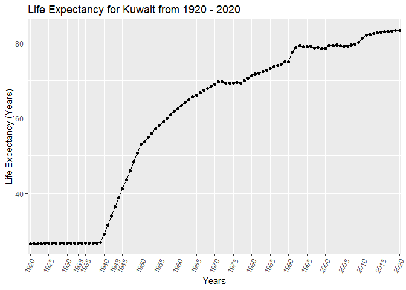

```r
life_exp_graphing %>%
  ggplot(aes(x = year, y = life_exp_yrs, group = 1)) +
  geom_line() +
  geom_point() +
  theme(axis.text.x = element_text(angle = 60, hjust = 1, size = 8)) +
  scale_x_discrete(breaks=c(1920, 1925, 1930, 1933, 1935, 1940, 1943, 1945, 1950, 1955, 1960, 1965, 1970, 1975, 1980, 1985, 1990, 1995, 2000, 2005, 2010, 2015, 2020)) +
  labs(x = "Years",
       y = "Life Expectancy (Years)",
       title = "Life Expectancy for Kuwait from 1920 - 2020")
```

```r
#From what I found online, it looks like this amazing improvement in life expectancy was helped by the boom in the petroleum industry that began in the 1930s.
```

## Population Growth

6. (3 points) Which 5 countries have had the highest population growth over the past 100 years (1920-2020)?

```r
popu_tidy %>%
  pivot_wider(names_from = year,
              names_prefix = "year_",
              values_from = population) %>%
  select(country, year_1920, year_2020) %>%
  mutate(growth = year_2020 - year_1920) %>%
  arrange(desc(growth)) %>%
  top_n(growth, n = 5)
```

```
## # A tibble: 5 x 4
##   country       year_1920  year_2020     growth
##   <fct>             <dbl>      <dbl>      <dbl>
## 1 India         317000000 1380000000 1063000000
## 2 China         472000000 1440000000  968000000
## 3 Indonesia      47300000  274000000  226700000
## 4 United States 111000000  331000000  220000000
## 5 Pakistan       21700000  221000000  199300000
```

7. (4 points) Produce a plot that shows the 5 countries that have had the highest population growth over the past 100 years (1920-2020). Which countries appear to have had exponential growth?

```r
popu_tidy_graphing <- popu_tidy %>%
  filter(year >= 1920, year <= 2020) %>%
  filter(country == "India" | country == "China" | country == "Indonesia" | country == "United States" | country == "Pakistan")
popu_tidy_graphing$year <- as.factor(popu_tidy_graphing$year)
```

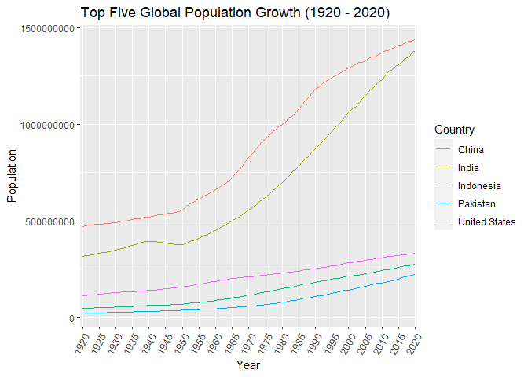

```r
popu_tidy_graphing %>%
  ggplot(aes(x = year, y = population, group = country, color = country)) +
  geom_line() +
  theme(axis.text.x = element_text(angle = 60, hjust = 1, size = 10)) +
  scale_x_discrete(breaks=c(1920, 1925, 1930, 1935, 1940, 1945, 1950, 1955, 1960, 1965, 1970, 1975, 1980, 1985, 1990, 1995, 2000, 2005, 2010, 2015, 2020)) +
  labs(x = "Year",
       y = "Population",
       title = "Top Five Global Population Growth (1920 - 2020)",
       color = "Country")
```

```r
#China and India have the greatest growth
```

## Income

The units used for income are gross domestic product per person adjusted for differences in purchasing power in international dollars.

8. (4 points) As in the previous questions, which countries have experienced the biggest growth in per person GDP. Show this as a table and then plot the changes for the top 5 countries. With a bit of research, you should be able to explain the dramatic downturns of the wealthiest economies that occurred during the 1980’s.

```r
income_tidy %>%
  pivot_wider(names_from = year,
              names_prefix = "year_",
              values_from = income_per_person) %>%
  select(country, year_1920, year_2020) %>%
  mutate(growth_gdp = year_2020 - year_1920) %>%
  arrange(desc(growth_gdp)) %>%
  top_n(growth_gdp, n = 5)
```

```
## # A tibble: 5 x 4
##   country    year_1920 year_2020 growth_gdp
##   <fct>          <dbl>     <dbl>      <dbl>
## 1 Qatar           2300    116000     113700
## 2 Luxembourg      5730     95100      89370
## 3 Singapore       2440     90500      88060
## 4 Brunei          2130     75100      72970
## 5 Ireland         5170     74100      68930
```

```r
#From what I found online, it looks like this huge change was caused by a very severe economic recession due to an energy crisis that took place in 1979.
```

```r
income_tidy_graphing <- income_tidy %>%
  filter(year >= 1920, year <= 2020) %>%
  filter(country == "Qatar" | country == "Luxembourg" | country == "Singapore" |
           country == "Brunei" | country == "Ireland")
income_tidy_graphing$year <- as.factor(income_tidy_graphing$year)
```

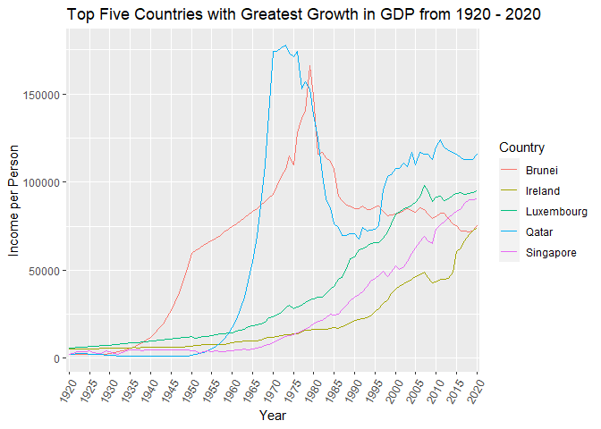

```r
income_tidy_graphing %>%
  ggplot(aes(x = year, y = income_per_person, group = country, color = country)) +
  geom_line() +
  theme(axis.text.x = element_text(angle = 60, hjust = 1, size = 10)) +
  scale_x_discrete(breaks=c(1920, 1925, 1930, 1935, 1940, 1945, 1950, 1955, 1960, 1965, 1970, 1975, 1980, 1985, 1990, 1995, 2000, 2005, 2010, 2015, 2020)) +
  labs(x = "Year",
       y = "Income per Person",
       title = "Top Five Countries with Greatest Growth in GDP from 1920 - 2020",
       color = "Country")
```

9. (3 points) Create three new objects that restrict each data set (life expectancy, population, income) to the years 1920-2020. Hint: I suggest doing this with the long form of your data. Once this is done, merge all three data sets using the code I provide below. You may need to adjust the code depending on how you have named your objects. I called mine `life_expectancy_100`, `population_100`, and `income_100`. For some of you, learning these `joins` will be important for your project.

life_expectancy_100

```r
life_expectancy_100 <- life_exp_tidy %>%
  filter(year >= 1920, year <= 2020)
life_expectancy_100
```

```
## # A tibble: 18,887 x 3
##    country      year life_exp_yrs
##    <fct>       <int>        <dbl>
##  1 Afghanistan  1920         30.6
##  2 Afghanistan  1921         30.7
##  3 Afghanistan  1922         30.8
##  4 Afghanistan  1923         30.8
##  5 Afghanistan  1924         30.9
##  6 Afghanistan  1925         31
##  7 Afghanistan  1926         31
##  8 Afghanistan  1927         31.1
##  9 Afghanistan  1928         31.1
## 10 Afghanistan  1929         31.2
## # ... with 18,877 more rows
```

population_100

```r
population_100 <- popu_tidy %>%
  filter(year >= 1920, year <= 2020)
population_100
```

```
## # A tibble: 19,695 x 3
##    country      year population
##    <fct>       <int>      <dbl>
##  1 Afghanistan  1920   10600000
##  2 Afghanistan  1921   10500000
##  3 Afghanistan  1922   10300000
##  4 Afghanistan  1923    9710000
##  5 Afghanistan  1924    9200000
##  6 Afghanistan  1925    8720000
##  7 Afghanistan  1926    8260000
##  8 Afghanistan  1927    7830000
##  9 Afghanistan  1928    7420000
## 10 Afghanistan  1929    7100000
## # ... with 19,685 more rows
```

income_100

```r
income_100 <- income_tidy %>%
  filter(year >= 1920, year <= 2020)
income_100
```

```
## # A tibble: 19,493 x 3
##    country      year income_per_person
##    <fct>       <int>             <dbl>
##  1 Afghanistan  1920              1490
##  2 Afghanistan  1921              1520
##  3 Afghanistan  1922              1550
##  4 Afghanistan  1923              1570
##  5 Afghanistan  1924              1600
##  6 Afghanistan  1925              1630
##  7 Afghanistan  1926              1650
##  8 Afghanistan  1927              1680
##  9 Afghanistan  1928              1710
## 10 Afghanistan  1929              1740
## # ... with 19,483 more rows
```

```r
gapminder_join <- inner_join(life_expectancy_100, population_100, by= c("country", "year"))
gapminder_join <- inner_join(gapminder_join, income_100, by= c("country", "year"))
gapminder_join
```

```
## # A tibble: 18,887 x 5
##    country      year life_exp_yrs population income_per_person
##    <fct>       <int>        <dbl>      <dbl>             <dbl>
##  1 Afghanistan  1920         30.6   10600000              1490
##  2 Afghanistan  1921         30.7   10500000              1520
##  3 Afghanistan  1922         30.8   10300000              1550
##  4 Afghanistan  1923         30.8    9710000              1570
##  5 Afghanistan  1924         30.9    9200000              1600
##  6 Afghanistan  1925         31      8720000              1630
##  7 Afghanistan  1926         31      8260000              1650
##  8 Afghanistan  1927         31.1    7830000              1680
##  9 Afghanistan  1928         31.1    7420000              1710
## 10 Afghanistan  1929         31.2    7100000              1740
## # ... with 18,877 more rows
```

```r
#so cool!!
```

10. (4 points) Use the joined data to perform an analysis of your choice. The analysis should include a comparison between two or more of the variables `life_expectancy`, `population`, or `income.`

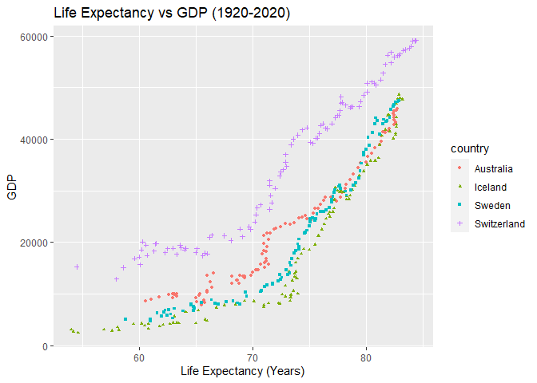

```r
gapminder_join %>%
  filter(country=="Australia" | country=="Sweden"| country=="Iceland"| country=="Switzerland") %>%
  ggplot(aes(x=life_exp_yrs, y=income_per_person, color=country, shape=country))+
  geom_point(alpha=1, size=01)+
  labs(title="Life Expectancy vs GDP (1920-2020)",
       x = "Life Expectancy (Years)",
       y =  "GDP")
```